# Running NIMBLE from R

# Testing NIMBLE in R - Basic Setup and Functionality

First we define the model code, its constants, data, and initial values for MCMC.

```r
# load library
library(nimble)
# Model code
pumpCode <- nimbleCode({
  for (i in 1:N){
      theta[i] ~ dgamma(alpha,beta)
      lambda[i] <- theta[i]*t[i]
      x[i] ~ dpois(lambda[i])
  }
  alpha ~ dexp(1.0)
  beta ~ dgamma(0.1,1.0)
})

# create constants, number of pumps (N = 10), and duration of operation for each pump (t)
pumpConsts <- list(N = 10,
                   t = c(94.3, 15.7, 62.9, 126, 5.24,
                       31.4, 1.05, 1.05, 2.1, 10.5))

# Data: number of failures over pump duration
pumpData <- list(x = c(5, 1, 5, 14, 3, 19, 1, 1, 4, 22))

# model initialization values
pumpInits <- list(alpha = 1, beta = 1,
                  theta = rep(0.1, pumpConsts$N))
```

Here x[i] is the number of failures recorded during a time duration of length t[i] for the i*th* pump. theta[i] is a failure rate, and the goal is estimate parameters alpha and beta.

Now lets create the model and look at some of its nodes.

```r
pump <- nimbleModel(code = pumpCode, name = "pump", constants = pumpConsts,
                    data = pumpData, inits = pumpInits)
```

```
Defining model
Building model
Setting data and initial values
Running calculate on model
  [Note] Any error reports that follow may simply reflect missing values in model variables.
Checking model sizes and dimensions
```

```r
pump$getNodeNames()
```

```
 [1] "alpha"               "beta"                "lifted_d1_over_beta" "theta[1]"            "theta[2]"            "theta[3]"
 [7] "theta[4]"            "theta[5]"            "theta[6]"            "theta[7]"            "theta[8]"            "theta[9]"
[13] "theta[10]"           "lambda[1]"           "lambda[2]"           "lambda[3]"           "lambda[4]"           "lambda[5]"
[19] "lambda[6]"           "lambda[7]"           "lambda[8]"           "lambda[9]"           "lambda[10]"          "x[1]"
[25] "x[2]"                "x[3]"                "x[4]"                "x[5]"                "x[6]"                "x[7]"
[31] "x[8]"                "x[9]"                "x[10]"
```

Thanks to the plotting capabilities of the igraph package that NIMBLE uses to represent the directed acyclic graph, we can plot the model.

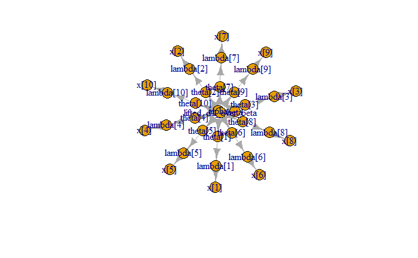

```r
pump$plotGraph()
```

Next we compile the model, which means generating C++ code, compiling that code, and loading it back into R with an object that can be used just like the uncompiled model. The values in the compiled model will be initialized from those of the original model in R, but the original and compiled models are distinct objects so any subsequent changes in one will not be reflected in the other.

```r
Cpump <- compileNimble(pump)
```

```
Compiling
  [Note] This may take a minute.
  [Note] Use 'showCompilerOutput = TRUE' to see C++ compilation details.
```

The most direct approach to invoking NIMBLE’s MCMC engine is using the nimbleMCMC function. This function would generally take the code, data, constants, and initial values as input, but it can also accept the (compiled or uncompiled) model object as an argument. It provides a variety of options for executing and controlling multiple chains of NIMBLE’s default MCMC algorithm, and returning posterior samples, posterior summary statistics, and/or WAIC values.

For example, to execute two MCMC chains of 10,000 samples each, and return samples, summary statistics, and WAIC values:

```r
mcmc.out <- nimbleMCMC(code = pumpCode, constants = pumpConsts,
                       data = pumpData, inits = pumpInits,
                       nchains = 2, niter = 10000,
                       summary = TRUE, WAIC = TRUE,
                       monitors = c('alpha','beta','theta'))
```

```
Defining model
Building model
Setting data and initial values
Running calculate on model
  [Note] Any error reports that follow may simply reflect missing values in model variables.
Checking model sizes and dimensions
Checking model calculations
Compiling
  [Note] This may take a minute.
  [Note] Use 'showCompilerOutput = TRUE' to see C++ compilation details.
running chain 1...
```

```
|-------------|-------------|-------------|-------------|
|-------------------------------------------------------|
```

```
running chain 2...
```

```
|-------------|-------------|-------------|-------------|
|-------------------------------------------------------|
There are individual pWAIC values that are greater than 0.4. This may indicate that the WAIC estimate is unstable (Vehtari et al., 2017), at least in cases without grouping of data nodes or multivariate data nodes.
```

# Testing NIMBLE in R - Chapter 5, conducting a linear regression

Generate and plot body mass data

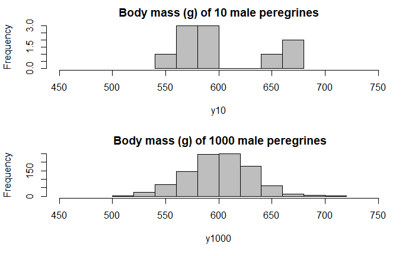

```r
### 5.2. Data generation
# Generate two samples of body mass measurements of male peregrines
y10 <- rnorm(n = 10, mean = 600, sd = 30) # Sample of 10 birds
y1000 <- rnorm(n = 1000, mean = 600, sd = 30) # Sample of 1000 birds

# Plot data
xlim = c(450, 750)
par(mfrow = c(2,1))
hist(y10, col = 'grey ', xlim = xlim, main = 'Body mass (g) of 10 male peregrines')
hist(y1000, col = 'grey', xlim = xlim, main = ' Body mass (g) of 1000 male peregrines')
```

Classic linear regression analysis

```r
### 5.3. Analysis using R
summary(lm(y1000 ~ 1))
```

[output not shown]

Analysis Using NIMBLE

```r
# Model code
bmassCode <- nimbleCode({
  # likelihood
 for(i in 1:nobs){
    mass[i] ~ dnorm(population.mean, precision)
 }
  # priors
 population.mean ~ dunif(0,5000)        # Normal parameterized by precision
 precision <- 1 / population.variance   # Precision = 1/variance
 population.variance <- population.sd * population.sd
 population.sd ~ dunif(0,100)
})
# Model parameters to report
bmassMonitors <- c("population.mean", "population.sd", "population.variance")

# model initialization values
bmassInits <- list(population.mean = rnorm(1,600), population.sd = runif(1, 1, 30))

# model constants
bmassConsts <- list(nobs = length(y1000))

# data
bmassData <- list(mass = y1000)

# Create & Compile the model
bmass <- nimbleModel(code = bmassCode, name = "bmass", constants = bmassConsts, data = bmassData, inits = bmassInits)
```

```
Defining model
Building model
Setting data and initial values
Running calculate on model
  [Note] Any error reports that follow may simply reflect missing values in model variables.
Checking model sizes and dimensions
```

```r
Cbmass <- compileNimble(bmass)
```

```
Compiling
  [Note] This may take a minute.
  [Note] Use 'showCompilerOutput = TRUE' to see C++ compilation details.
```